# Simulating Multi-Environment Trials

`simTrialData()` and `plot_simTrialData()`

Author

Julian Taylor

Published

October 9, 2026

[figure not shown]

## Overview

`simTrialData()` generates realistic multi-environment trial (MET) datasets for plant breeding research. It produces data whose true genetic covariance structure is known, making it ideal for demonstrating the other biomAid functions, exploring model behaviour, and designing simulation studies.

Two trial structures are supported:

| Structure | Description |
| --- | --- |
| **MET-only** (`treatments = NULL`) | Randomised complete block design (RCB). Varieties are the sole genetic treatment. One `yield` column is returned. |
| **Split-plot MET** (`treatments = c(...)`) | Whole-plot treatment strips with variety sub-plots. Adds `Treatment` and `TSite` columns to the data. |

The genetic structure can be controlled in two ways:

| Mode | Argument | Description |
| --- | --- | --- |
| **Auto** | `G = "auto"` (default) | A random symmetric positive-definite (SPD) covariance matrix with pairwise genetic correlations in a user-specified range. |
| **User-supplied** | `G = matrix` | A validated SPD matrix supplied by the analyst — useful when a known genetic structure is required. |

The incidence structure (which varieties appear at which sites) can be **balanced** (every variety at every site), **unbalanced** (auto-generated two-tier structure with core and regular varieties), or supplied by the user as a binary matrix.

`plot_simTrialData()` provides four complementary visualisations that together describe the simulated data structure from every angle: field layout, variety connectivity, genetic correlations, and the true underlying genetic values.

## Mathematical Framework

### Trial structure

Consider a MET with $n$ varieties, $s$ environments (sites), $r$ replicates, and $N = \sum_{j=1}^s n_j r$ total plots, where $n_j \le n$ is the number of varieties observed at site $j$. Let $\mathbf{y} = (\mathbf{y}_1^\top,\ldots,\mathbf{y}_s^\top)^\top \in \mathbb{R}^{N}$ be the vector of observations conformably partitioned by sites, then the multi-environment trial (MET) linear mixed model is

$$\mathbf{y}
= \mathbf{X}\boldsymbol{\mu}
+ \mathbf{Z}^{\mathrm{var}}\mathbf{u}
+ \mathbf{Z}^{\mathrm{rep}}\boldsymbol{\rho}
+ \mathbf{Z}^{\mathrm{row}}\boldsymbol{\phi}
+ \mathbf{Z}^{\mathrm{col}}\boldsymbol{\xi}
+ \boldsymbol{\varepsilon},$$

where:

- $\mathbf{X} \in \{0,1\}^{N \times s}$ is the site fixed-effect incidence matrix and $\boldsymbol{\mu} = (\mu_1,\ldots,\mu_s)^\top$ the vector of site means, drawn independently as $\mu_j \stackrel{\mathrm{ind}}{\sim} \mathcal{N}(\mu_0,\, \sigma^2_{\mathrm{site}})$;
- $\mathbf{u} = (\mathbf{u}_1^\top,\ldots,\mathbf{u}_s^\top)^\top \in \mathbb{R}^{n_{\bullet}}$, $n_{\bullet} = \sum_j n_j$, stacks the true genetic values for the observed varieties at each site;
- $\boldsymbol{\rho}$, $\boldsymbol{\phi}$, $\boldsymbol{\xi}$ are the peripheral replicate, row, and column random effects across all sites;
- $\boldsymbol{\varepsilon} (\mathbf{\varepsilon}_1^\top,\ldots,\mathbf{\varepsilon}_s^\top)^\top \in \mathbb{R}^N$ is vector of residuals conformably partitioned by sites.

All random terms are mutually independent. The design based random terms are homogeneous within each site, so their variance matrices take a natural direct-sum form across environments:

$$\operatorname{Var}(\boldsymbol{\rho})
= \oplus_{j=1}^{s} \sigma^2_{\mathrm{rep}}\,\mathbf{I}_{r},
\qquad
\operatorname{Var}(\boldsymbol{\phi})
= \oplus_{j=1}^{s} \sigma^2_{\mathrm{row}}\,\mathbf{I}_{R_j},
\qquad
\operatorname{Var}(\boldsymbol{\xi})
= \oplus_{j=1}^{s} \sigma^2_{\mathrm{col}}\,\mathbf{I}_{C_j},$$

where $R_j$ and $C_j$ are the numbers of field rows and columns at site $j$ (see Layout).

### Residual variance structure

The plot-level residual $\boldsymbol{\varepsilon}$ is decomposed into a **spatially correlated** component $\boldsymbol{\eta}$ and an independent **nugget** $\boldsymbol{\delta}$:

$$\boldsymbol{\varepsilon} = \boldsymbol{\eta} + \boldsymbol{\delta},
\qquad \boldsymbol{\eta} \perp \boldsymbol{\delta},
\qquad \boldsymbol{\delta} \sim \mathcal{N}(\mathbf{0},\,
\sigma^2_{\mathrm{error}}\,\mathbf{I}_N).$$

The spatial component uses a **separable first-order autoregressive** (AR1) structure across the field rows and columns within each site. Stacking across all $s$ sites using the direct-sum notation, the full residual variance is

$$\operatorname{Var}(\boldsymbol{\varepsilon})
= \bigoplus_{j=1}^{s}
\Bigl[
\sigma^2_{\mathrm{spatial}}\,
\mathbf{H}_{C_j}\!\left(\rho^{(j)}_{\mathrm{col}}\right)
\otimes
\mathbf{H}_{R_j}\!\left(\rho^{(j)}_{\mathrm{row}}\right)
+\,
\sigma^2_{\mathrm{error}}\,\mathbf{I}_{R_j C_j}
\Bigr].$$

where $\mathbf{H}_m(\rho)$ is the $m \times m$ AR1 correlation matrix with $(i,k)$ element $\rho^{|i-k|}$, and $\rho^{(j)}_{\mathrm{row}},\, \rho^{(j)}_{\mathrm{col}} \in (-1, 1)$ are the site-specific AR1 parameters.

The AR1 parameters can be **fixed** across all sites (a scalar supplied to `ar1_rho_row` / `ar1_rho_col`) or **site-varying**, with each $\rho^{(j)}$ drawn independently and uniformly from a user-supplied range $[r_{\min}, r_{\max}]$, producing a different spatial structure at every trial location. The simulation uses the efficient Kronecker–Cholesky factorisation

$$\boldsymbol{\eta}_j = \sigma_{\mathrm{spatial}}\,
\mathbf{L}_{R_j}(\rho^{(j)}_{\mathrm{row}})\,
\mathbf{Z}_j\,
\mathbf{L}_{C_j}(\rho^{(j)}_{\mathrm{col}})^\top,
\quad \mathbf{Z}_j \sim \mathcal{MN}(\mathbf{0},\mathbf{I}_{R_j},\mathbf{I}_{C_j}),$$

where $\mathbf{L}_m(\rho) = \operatorname{chol}\!\bigl(\mathbf{H}_m(\rho)\bigr)^\top$ is the lower Cholesky factor, avoiding construction of the full $R_j C_j \times R_j C_j$ covariance matrix.

When `ar1_rho_row = ar1_rho_col = NULL` (the default) the spatial component is absent and $\operatorname{Var}(\boldsymbol{\varepsilon}) = \sigma^2_{\mathrm{error}}\,\mathbf{I}_N$.

Default variance parameters are $\sigma_{\mathrm{rep}} = 150$, $\sigma_{\mathrm{row}} = 80$, $\sigma_{\mathrm{col}} = 60$, $\sigma_{\mathrm{error}} = 350$, and — when the AR1 spatial component is active — $\sigma_{\mathrm{spatial}} = \sigma_{\mathrm{error}} / 2 = 175$ by default. All six scale-dependent parameters are automatically proportioned to `site_mean` when only `site_mean` is changed by the user.

### Genetic variance and the G-matrix

The genetic term $\mathbf{u}$ is one of the key vectors of the simulation. Let $\mathbf{U} \in \mathbb{R}^{n \times J}$ be the complete matrix of true genetic values for all $n$ varieties across all $J$ groups, where $J = s$ for MET-only designs and $J = s \times t$ for multi-treatment designs with $t$ treatments. Because varieties are genetically independent realisations from the same $J$-variate distribution,

$$\operatorname{vec}(\mathbf{U})
\sim \mathcal{N}\!\left(\mathbf{0},\;\mathbf{G} \otimes \mathbf{I}_n\right),$$

where $\mathbf{G}$ is a $J \times J$ symmetric positive-definite genetic covariance matrix. The Kronecker structure encodes two things simultaneously: the $\mathbf{I}_n$ factor asserts that varieties are genetically independent of one another, while $\mathbf{G}$ governs how each variety’s genetic value co-varies **across** environments. Specifically, $G_{jj}$ is the genetic variance at environment $j$ and $G_{jk}/\sqrt{G_{jj}G_{kk}}$ is the genetic correlation between environments $j$ and $k$.

For balanced designs ($n_j = n$ for all $j$), $\mathbf{u} = \operatorname{vec}(\mathbf{U})$ exactly, and $\operatorname{Var}(\mathbf{u}) = \mathbf{G} \otimes \mathbf{I}_n$. For unbalanced designs, $\mathbf{u}_j = \mathbf{A}_j\,\mathbf{U}_{:j}$, where $\mathbf{A}_j \in \{0,1\}^{n_j \times n}$ is the variety selection matrix derived from column $j$ of the binary incidence matrix $\mathbf{I}$ (see Incidence structure).

The rows of $\mathbf{U}$ are drawn from a multivariate normal distribution via the Cholesky decomposition of the $J \times J$ genetic covariance matrix $\mathbf{G}$:

$$\mathbf{U} = \mathbf{Z} \mathbf{L},
\quad
\mathbf{Z}_{ij} \stackrel{\text{iid}}{\sim} \mathcal{N}(0, 1),
\quad
\mathbf{L}^\top \mathbf{L} = \mathbf{G},$$

where $\mathbf{L}$ is the upper Cholesky factor. Each row $\mathbf{u}_i = (u_{i1}, \ldots, u_{iJ})^\top$ of $\mathbf{U}$ gives the true genetic values for variety $i$ across all $J$ groups, satisfying

$$\mathbf{U} \sim \mathcal{MN}_{n \times J}(\mathbf{0},\, \mathbf{I}_n,\, \mathbf{G}),$$

i.e. varieties are independent realisations from $\mathcal{N}(\mathbf{0}, \mathbf{G})$. $\mathbf{G}$ is returned directly as `params$G`.

#### Auto-generated $\mathbf{G}$

When `G = "auto"` (the default), a random SPD correlation matrix $\mathbf{R}$ is constructed such that the off-diagonal elements lie approximately in the user-specified interval $[r_\text{min},\, r_\text{max}]$ (controlled by `sim.options$g_cor_min` and `sim.options$g_cor_max`, defaulting to 0.20 and 0.90). This is achieved by:

1. Generating a random factor loading matrix $\boldsymbol{\Lambda} \in \mathbb{R}^{J \times k}$ with $k = \lfloor J/3 \rfloor$ latent factors and sign-flips on factors 2 through $k$ to induce realistic GEI.
2. Computing the implied correlation matrix $\mathbf{R}^\text{raw} = \operatorname{Cov2Cor}(\boldsymbol{\Lambda} \boldsymbol{\Lambda}^\top + \psi \mathbf{I})$.
3. Linearly rescaling all off-diagonal elements of $\mathbf{R}^\text{raw}$ from their observed range onto $[r_\text{min},\, r_\text{max}]$.
4. Scaling the resulting correlation matrix by $\sigma^2_\text{genetic}$ to produce $\mathbf{G} = \sigma^2_\text{genetic} \mathbf{R}$.

The final $\mathbf{G}$ has unit genetic SD of approximately $\sigma_\text{genetic}$ in every environment (default 250) and all pairwise genetic correlations in $[r_\text{min},\, r_\text{max}]$.

### Incidence structure

Let $\mathbf{I} \in \{0,1\}^{n \times s}$ be the incidence matrix, where $I_{ij} = 1$ means variety $i$ is observed at site $j$. Under the **unbalanced** auto-generation algorithm, varieties are partitioned into:

- **Core** varieties (proportion `core_pct`): present in at least `core_min_sites_pct` $\times s$ sites.
- **Regular** varieties (remaining): present in a random number of sites drawn uniformly from $[\,\lceil r_\text{min} \cdot s \rceil,\; \lfloor r_\text{max} \cdot s \rfloor\,]$.

Two hard constraints are enforced: every variety must appear in at least one site, and every site must contain at least $\max(\lceil n \cdot \texttt{min\_vars\_pct} \rceil,\; 2)$ varieties.

All $n$ varieties have **true** genetic values at every site regardless of incidence — an unobserved variety simply contributes no plots to that site’s trial. This is the genotyping model: every variety is genomically characterised but only a subset are phenotyped in each environment.

### Layout

Within each site, the $n_j = \sum_i I_{ij}$ observed varieties are assigned to a rectangular field grid of dimension $r_j \times c_j$ per replicate, where $r_j$ and $c_j$ are chosen to minimise the difference between rows and columns (nearest-to-square factorisation of $n_j$). Row and column dimensions therefore vary across sites in unbalanced designs.

## Example 1 — Balanced MET

A simple balanced MET-only trial: 20 varieties, six sites, two replicates, auto-generated $\mathbf{G}$.

```r
out1 <- simTrialData(
  nvar      = 20L,
  nsite     = 6L,
  nrep      = 2L,
  seed      = 101L,
  verbose   = FALSE
)
```

The `params` list records the true simulation parameters. The genetic correlations between sites can be inspected directly:

```r
round(cov2cor(out1$params$G), 2)
```

```
     Env1 Env2 Env3 Env4 Env5 Env6
Env1 1.00 0.87 0.41 0.90 0.90 0.29
Env2 0.87 1.00 0.35 0.86 0.88 0.24
Env3 0.41 0.35 1.00 0.50 0.32 0.89
Env4 0.90 0.86 0.50 1.00 0.88 0.37
Env5 0.90 0.88 0.32 0.88 1.00 0.20
Env6 0.29 0.24 0.89 0.37 0.20 1.00
```

The `"trial"` plot type renders the Row $\times$ Column field grid for every site, faceted in a 2 $\times$ 3 arrangement. Setting `fill = "yield"` maps the continuous response onto a viridis colour scale — this is the raw yield surface as it would appear in a field book, before any statistical adjustment.

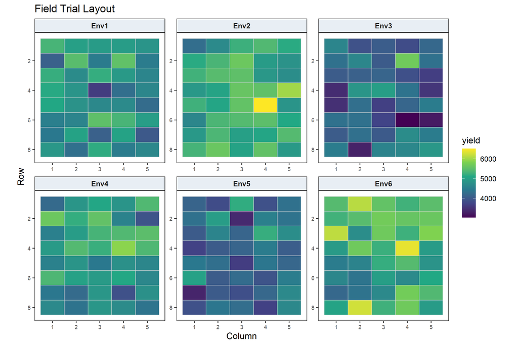

```r
plot_simTrialData(
  out1,
  type = "trial",
  fill = "yield",
  ncol = 3L
)
```

## Example 2 — Balanced MET with treatments

Adding three treatment levels converts the trial to a split-plot design. The field layout now shows treatment strips (whole plots) within each replicate, with varieties randomised within strips.

```r
out2 <- simTrialData(
  nvar        = 20L,
  nsite       = 6L,
  treatments  = c("T0", "T1", "T2"),
  nrep        = 2L,
  seed        = 202L,
  verbose     = FALSE,
  sim.options = list(treat_effects = c(0, 200, 400))
)
```

### Genetic correlations across Treatment $\times$ Site groups

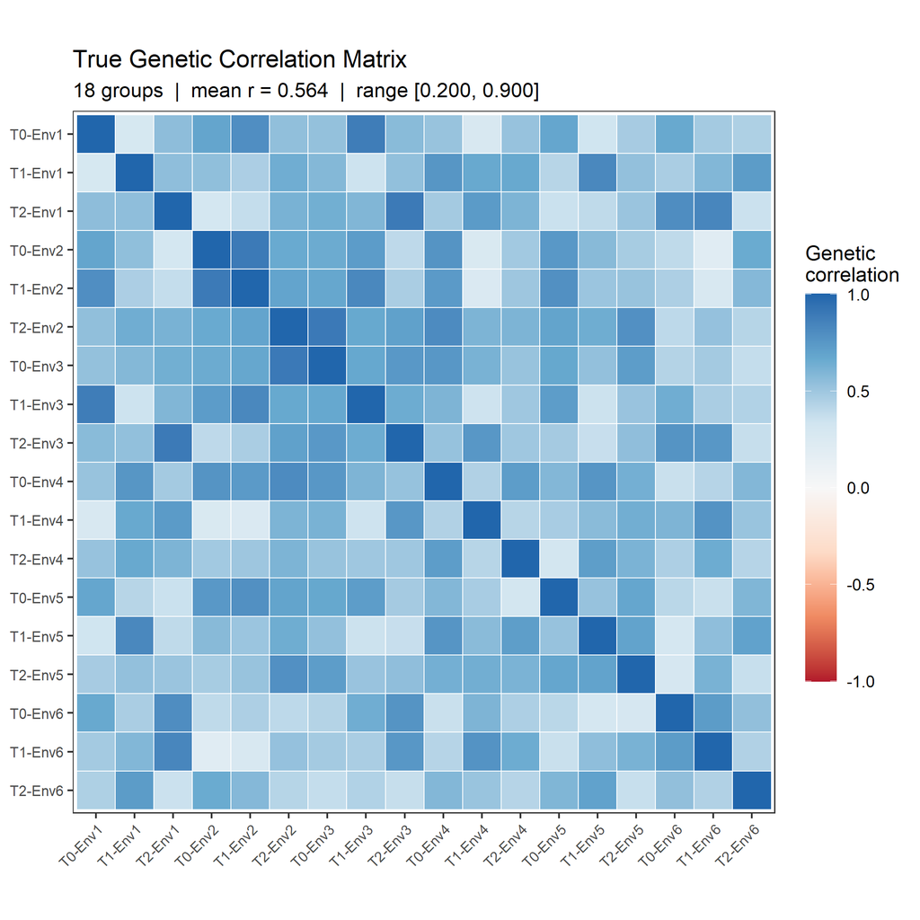

```r
plot_simTrialData(
  out2,
  type = "correlation"
)
```

### Field layout coloured by treatment

Setting `fill = "Treatment"` colours each plot tile by its assigned treatment, making the strip-plot structure immediately visible within every replicate. Adding `label = "Variety"` overlays abbreviated variety names so the within-strip randomisation can be verified.

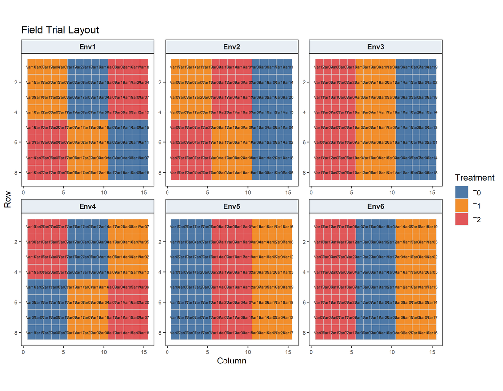

```r
plot_simTrialData(
  out2,
  type  = "trial",
  fill  = "Treatment",
  label = "Variety",
  ncol  = 3L
)
```

## Example 3 — Unbalanced MET with auto incidence

Increasing the number of varieties and switching to `incidence = "unbalanced"` generates a realistic two-tier connectivity pattern, as is common in national variety trials where a core set of checks is tested everywhere and candidate varieties appear in a subset of environments.

```r
out3 <- simTrialData(
  nvar      = 40L,
  nsite     = 6L,
  nrep      = 2L,
  incidence = "unbalanced",
  seed      = 303L,
  verbose   = FALSE
)
```

### Connectivity summary

```r
inc <- out3$params$incidence
cat(sprintf("Varieties per site : mean = %.1f,  range [%d, %d]\n",
            mean(colSums(inc)), min(colSums(inc)), max(colSums(inc))))
```

```
Varieties per site : mean = 25.7,  range [22, 32]
```

```r
cat(sprintf("Sites per variety  : mean = %.1f,  range [%d, %d]\n",
            mean(rowSums(inc)), min(rowSums(inc)), max(rowSums(inc))))
```

```
Sites per variety  : mean = 3.8,  range [3, 5]
```

### Incidence plot

The `"incidence"` plot type renders a Variety $\times$ Site tile grid. Blue tiles indicate observed combinations; grey tiles are absent. Varieties are sorted top-to-bottom by decreasing site count (most-connected at the top). Each variety label is annotated with its site count `[n]`; each site column header shows its variety count `[n]`.

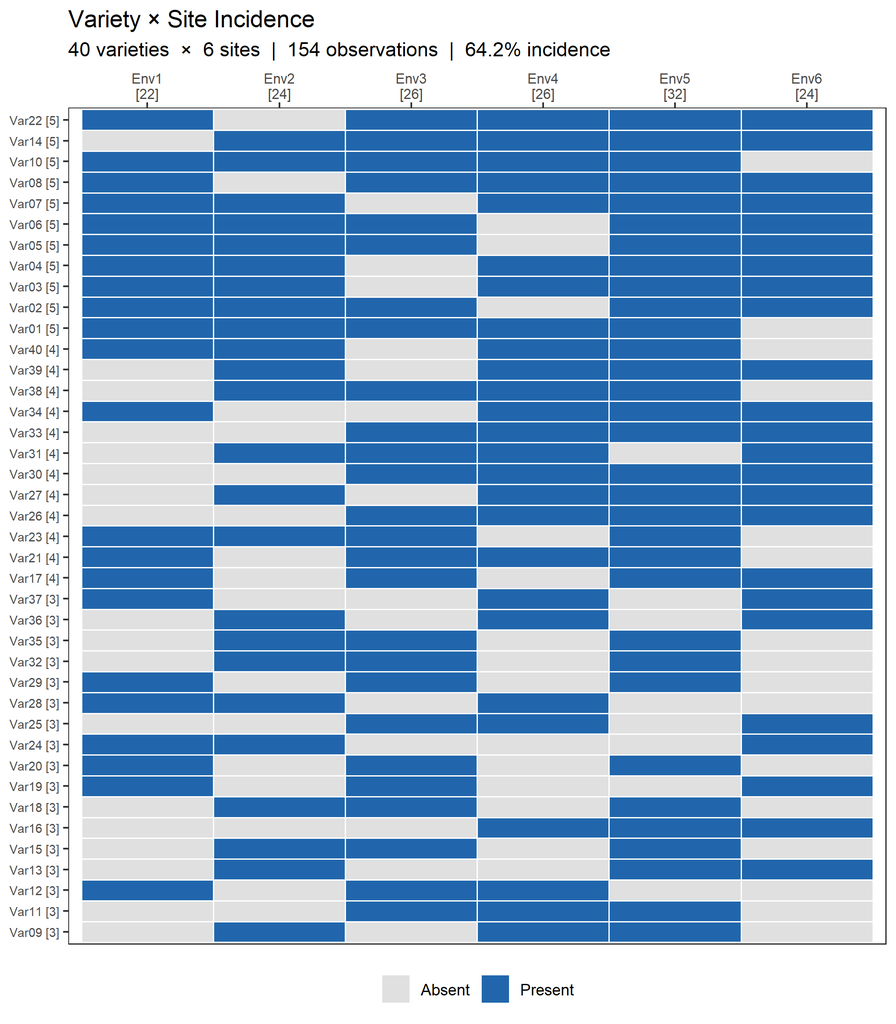

```r
plot_simTrialData(
  out3,
  type = "incidence"
)
```

The two-tier structure is clear: a band of blue-heavy rows at the top corresponds to the core varieties (present at most sites), with a gradient of decreasing connectivity towards the bottom. Sites with fewer varieties often reflect a constraint on trial capacity. This plot is particularly useful before fitting models — a site with very few varieties or a variety appearing at only one site may need special treatment in the random structure.

## Example 4 — Unbalanced MET with user-supplied incidence

In some settings the analyst needs full control over which varieties appear at which sites — for example, when mimicking a real trial network or stress-testing a specific connectivity pattern. A binary matrix can be passed directly to the `incidence` argument.

```r
set.seed(404L)
nvar  <- 40L
nsite <- 6L
inc4  <- matrix(0L, nrow = nvar, ncol = nsite)

# Hub sites: all varieties present
inc4[, 1:3] <- 1L

# Satellite sites: first 10 varieties (checks) + 50% random sample of rest
checks <- 1:10
rest   <- 11:nvar
for (s in 4:6) {
  chosen       <- sample(rest, size = ceiling(length(rest) * 0.50))
  inc4[checks, s] <- 1L
  inc4[chosen,  s] <- 1L
}
```

```r
out4 <- simTrialData(
  nvar      = nvar,
  nsite     = nsite,
  nrep      = 2L,
  incidence = inc4,
  seed      = 404L,
  verbose   = FALSE
)
```

### BLUP heatmap — the true GEI surface

The `"blup"` plot type maps the true genetic BLUPs ($\mathbf{U}$) onto a Variety $\times$ Site heatmap using a diverging RdBu colour scale centred at zero. Varieties are sorted by decreasing mean BLUP across all sites (best overall performer at the top). This visualisation reveals the genotype-by-environment interaction (GEI) structure directly from the data-generating model and can be used to validate fitted models.

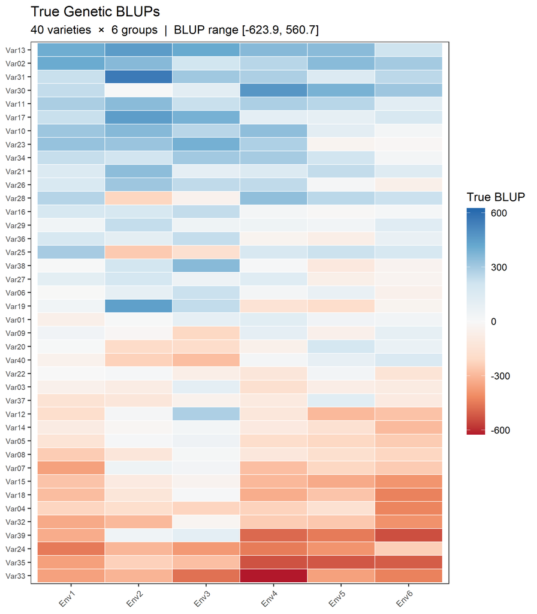

```r
plot_simTrialData(
  out4,
  type = "blup"
)
```

Strong GEI is evident where colours change markedly across a variety’s row — a variety that is dark blue (high BLUP) at some sites and red (low BLUP) at others is experiencing pronounced rank changes. Varieties that maintain a consistent colour across all six sites are stably ranked across environments, a pattern that an FA(1) model would capture with a large first-factor loading.

## Summary

### `simTrialData()` key arguments

| Argument | Default | Description |
| --- | --- | --- |
| `nvar` | `20` | Number of varieties |
| `nsite` | `10` | Number of environments |
| `treatments` | `NULL` | Character vector of treatment labels, or `NULL` for MET-only |
| `nrep` | `2` | Replicates per environment |
| `G` | `"auto"` | `"auto"` for random SPD matrix, or user-supplied $J \times J$ SPD matrix |
| `incidence` | `"balanced"` | `"balanced"`, `"unbalanced"`, or user-supplied binary matrix |
| `seed` | `NULL` | Integer seed for reproducibility |
| `verbose` | `TRUE` | Print design summary and suggested ASReml-R model |
| `sim.options` | `list()` | Fine-grained control: `site_mean`, `site_sd`, `sigma_genetic`, `rep_sd`, `row_sd`, `col_sd`, `error_sd`, `ar1_rho_row`, `ar1_rho_col`, `sigma_spatial`, `g_cor_min`, `g_cor_max`, `core_pct`, and more |

### `simTrialData()` return value

| Element | Description |
| --- | --- |
| `$data` | Plot-level data frame (Site, Variety, Rep, Row, Column, yield; plus Treatment, TSite for split-plot) |
| `$params$G` | True $J \times J$ genetic covariance matrix |
| `$params$incidence` | $n \times s$ integer incidence matrix |
| `$params$g_arr` | $n \times J$ matrix of true genetic BLUPs (all varieties, all groups) |
| `$params$site_means` | True site mean yields |
| `$params$treat_effects` | True treatment fixed effects (split-plot only) |
| `$params$ar1` | List of `rho_row`, `rho_col` (named per-site vectors) and `sigma_spatial` (when AR1 spatial is active) |

### `plot_simTrialData()` types

| Type | Key arguments | Best for |
| --- | --- | --- |
| `"trial"` | `fill`, `label`, `sites`, `ncol` | Field layout, yield surface, block/treatment structure |
| `"incidence"` | `sort` | Variety connectivity in unbalanced designs |
| `"correlation"` | — | True genetic correlation between environments |
| `"blup"` | `sites`, `sort` | True GEI surface; validating fitted FA models |

All types support `return_data = TRUE` to extract the underlying data frame and further customise the plot with standard ggplot2 additions.

## References

Smith, A., Cullis, B. & Thompson, R. (2001). Analysing variety by environment data using multiplicative mixed models and adjustments for spatial field trend. *Biometrics*, **57**(4), 1138–1147. https://doi.org/10.1111/j.0006-341X.2001.01138.x